# manual

## Manual de salga

SALGA significa System for Automated Learning based in Genetics Algorithms, y es un programa desarrollado en python para el simular la evolución por selección natural de los individuos de una población de soluciones a un problema. Está orientado tanto a docencia como a desarrollo de proyectos en este campo.

### Primeros pasos

##### Instalación

Descomprimir el archivo salga-xxx.zip.

El ordenador deberá tener instalado python 3.x. Para algunos ejemplos también deberá estar instalado el módulo matplotlib. En algunas distribuciones de linux puede ser necesario instalar además el paquete “python-tk”.

##### Ejecutar el programa Salga

En windows, ejecutar salga.pyc con doble click. En MacOSX y en linux, abrir un terminal y teclear “python salga.pyc”.

#### Definición del fitness, alfabeto y tipo de GA

Por su propia naturaleza, los Algoritmos Genéticos requieren, para ser adaptados a un problema concreto, que se defina una función de fitness (o función de calidad) que indica cómo de bueno es un individuo particular de cara a resolver un determinado problema. Éste fitness es la parte dependiente del dominio y debe programarse previamente para que el sistema pueda aplicarse al problema concreto.

Adicionalmente puede definirse una función phenotype que permita obtener una representación del individuo a evaluar a partir del cromosoma que lo describe. Por otro lado debemos seleccionar el tipo de algoritmo genético a utilizar (classic, floating o permutation) e indicar el alfabeto a utilizar en el problema.

##### Sobre el tipo de Algoritmo Genético

El tipo de Algoritmo Genético a utilizar puede ser:

- Classic
  - El alfabeto es un conjunto finito de símbolos.
  - La mutación se realiza a nivel de gen, eligiendo un nuevo valor del alfabeto.
  - El emparejamiento se realiza cortando las cadenas de los padres en un punto aleatorio y pegándolas cruzadas.
- Floating
  - El alfabeto se forma con todos los posibles valores flotantes en un intervalo [a,b] definido en el campo alfabeto.
  - La mutación se realiza un salto aleatorio desde el valor actual con distribución gausiana y temple simulado.
  - El emparejamiento se realiza igual que en el modo classic.
- Permutation
  - El alfabeto es un conjunto finito de símbolos.
  - Un cromosoma se forma por una permutación concreta del alfabeto, es decir, la longitud del cromosoma es la longitud del alfabeto.
  - La mutación consiste en intercambiar dos genes de posición.
  - El emparejamiento se construye copiando una subsecuencia del padre A y rellenando el resto con los valores que no están, tomándolos del padre B y manteniendo el orden parcial, aunque no la posición.

##### Sobre el alfabeto

Dependiendo del tipo de Algoritmo Genético elegido, el alfabeto se especifica de diferente modo:

- En ‘classic’, el alfabeto se representa por una lista de símbolos separados por comas y entre corchetes. Ejemplo: [0, 1] ➜ alfabeto binario.
- En ‘floating’, el alfabeto se especifica por el par de valores que definen el intervalo, entre corchetes. Ejemplo: [0, 10] ➜ todos los valores flotantes en el intervalo [0, 10].
- En permutation, el alfabeto se representa por una lista de símbolos separados por comas y entre corchetes, igual que en el modo ‘classic’. Ejemplo: [1, 2, 3, 4, 5] ➜ permutaciones de los números naturales del 1 al 5.

##### Sobre el fitness

La definición del fitness se realizará en un archivo python independiente que se cargará posteriormente desde el programa salga. Veamos un ejemplo sencillo cuyo objetivo es encontrar el número x tal que x^2 sea 488670902500:

```
import math
target = 488670902500

def phenotype (chromosome): # computes the decimal number represented by the chromosome
    res = 0
    l = len(chromosome)
    for v in range(l):
        if chromosome[l-v-1] != 0: res += 2**v
            return res

def fitness (chromosome): # aproximates x^2 = target
    fen = phenotype(chromosome)
    return 1.0 / (1.0 + abs(target - fen**2)) # maximum value when fen**2
```

La función fitness devuelve un valor tanto más alto cuanto más cercano es el número representado por un cromosoma a nuestro objetivo. Se ha construido además de modo que su máximo valor posible es 1.0, lo cual es bastante conveniente para la representación gráfica y para detener automáticamente el proceso evolutivo cuando el fitness del mejor individuo sea 1.

##### Carga de parámetros

Es posible cargar valores para los parámetros cuando se realiza la carga del fitness, tales como el alfabeto, las probabilidades de mutación y emparejamiento, la longitud del cromosoma y el método a utilizar, entre otros.

La carga de parámetros desde el archivo de fitness se realiza mediante un diccionario llamada 'parameters'. Las claves del diccionarios pueden tomar los valores siguientes:

- 'alphabet': el alfabeto a usar. Tipo: lista.
- 'type': tipo de genético a utilizar. Tipo: string
- 'elitism': Si se activa elitismo. Tipo: boolean.
- 'memetic': Si se usa memético. Tipo: boolen.
- 'norm': Si se usa normalización. Tipo: boolean.
- 'unique': Si se fuerza a que cada individuo sea único. Tipo: boolean.
- 'normfactor': Factor de normalización. Tipo: float.
- 'pmut': Probabilidad de mutación. Tipo: float.
- 'pcross': Probabilidad de emparejamiento. Tipo: float.
- 'chromsize': Tamaño del cromosoma. Tipo: int.
- 'popsize: Tamaño de la población. Tipo: int.
- 'target': fitness objetivo. Tipo: float.
- 'tournament': Tamaño de torneo. Tipo: float.
- 'seed': Individuo semilla para evolución 'seed'. Tipo: lista.

#### Significado/Uso de las distintas opciones del programa

##### Controles

1. ‘**Selección del tipo de genéticoa utilizar**’ ➜ puede ser classic, floating o permutation. Cada tipo tiene sus propia interpretación del alfabeto y sus propios operadores de emparejamiento y mutación.
2. ‘**Load Fitness Function**’ ➜ carga el código python que define el fitness y en su caso el phenotype.
3. ‘**Init**’ ➜ crea la población inicial con valores aleatorios.
4. ‘**Learn**’ ➜ inicia el proceso evolutivo.
5. ‘**Pmut**’ ➜ probabilidad de mutación de un gen.
6. ‘**Pcross**’ ➜ probabilidad de emparejar dos individuos una vez seleccionados.
7. ‘**Elitism**’ ➜ indica si hay que usar elitismo. Si es el caso, el mejor individuo de cada generación se guarda para la generación siguiente, previniendo su desaparición.
8. ‘**Norm**’ ➜ normaliza los valores del fitness para evitar problemas deno linealidad de la función de fitness.
9. ‘**Chrom.size**’ ➜ longitud de cromosoma a utilizar.
10. ‘**Population**’ ➜ tamaño de la población.
11. ‘**Ω**’ ➜ alfabeto a utilizar.
12. ‘**Target fit.**’ ➜ fitness objetivo para finalizar el proceso. Se recomienda definir el fitness para que el máximo target posible sea 1.
13. ‘**Traceperiod**’ ➜ cada cuántas generaciones actualiza la gráfica y la información presentada.
14. ‘**Load**’ ➜ carga una población previamente almacenada.
15. ‘**Save**’ ➜ graba la población actual.
16. ‘**Export**’ ➜ exporta la población actual en un formato de texto que pueda ser importado por otros programas.
17. ‘**About**’ ➜ muestra créditos del programa.
18. ‘**Quit**’ ➜ finaliza el programa.
19. ‘**Help**’ ➜ abre esta ayuda.

##### Información presentada

1. ‘**Best fitness**’ ➜ fitness del mejor individuo de la población.
2. ‘**Mean fitness**’ ➜ fitness medio de la población.
3. ‘**Diversity** ➜ diversidad de la población.
4. ‘**Epoch**’ ➜ generaciones transcurridas en la evolución en marcha.
5. ‘**Bst**’ ➜ fenotipo del mejor individuo en la generación actual, es decir, mejor solución al problema hasta el momento.

#### Procedimiento para generar una solución

1. Seleccionar tipo de Algoritmo Genético autilizar.
2. Cargar la función de fitness con ‘Load fitness’.
3. Definir el alfabeto a utilizar.
4. Ajustar los diferentes parámetros (Pmut, Pemp, etc.) o dejar los valores por defecto.
5. Click en ‘Learn’.
6. El entrenamiento puede pararse a mano dando click en la opción ‘Stop’ o automáticamente cuando el mejor individuo de la población tenga un fitness igual o mayor a ‘Target fit.‘.

##### Interpretación de los valores de entrenamiento

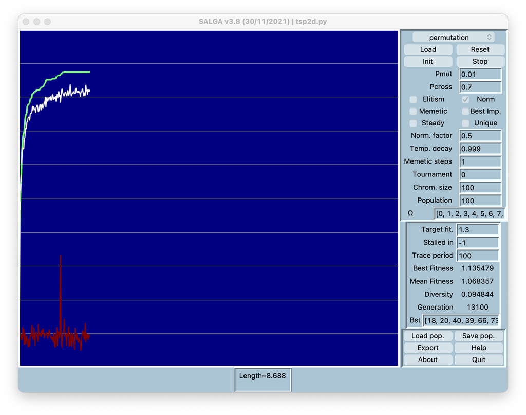

Colores de las líneas

1. Blanco: fitness medio de la población.
2. Verde: fitness del mejor individuo.
3. Rojo: diversidad de la población.
4. Gris: subdivisiones del error en pasos del 10% del “targetfitness”, es decir, el punto en que se detendrá la evolución.

#### Ejemplo final

Se trata del problema de las N-reinas modelizado como permutación. Puesto que por construcción dos reinas nunca pueden estar en la misma columna, asignamos a cada gen un entero que indica la fila en la que está, y la columna es el índice en la lista mod N.

```
import genetic # para usar errot2fit

# pide el número de reinas
import tkinter.simpledialog
nr = tkinter.simpledialog.askstring('Parameter', 'How many queens?', initialvalue='32')
N = int(nr)

def count (ch): # cuenta el número de reinas mal colocadas
    mal = 0
    for i in range(len(ch)): # comprueba si está bien colocada
        for j in range(i+1,len(ch)):
            if ch[i]==ch[j]: # si se comen en horizontal (en vertical no pueden comerse por construcción)
                mal += 1
            elif abs(ch[i]-ch[j]) == abs(i-j): # si se comen en diagonal
                mal += 1
    return mal

def phenotype (ch):
    res = 'Unsolved: %d\n' % count(ch)
    res += f'{ch}'
    return res

def fitness (ch):
    # cuenta el número de reinas que cada una puede comerse
    return genetics.error2fit(count(ch), 10)

# fija parámetros
parameters = {'chromsize': N, 'alphabet':list(range(N)), 'pmut': 1/N, 'norm':True, 'normfactor':0.9, 'target':1.0, 'type':'permutation'}
```